# GIS for Ag: Raster Data for Crop Cover in Merced County

Created by Madeline Brown

01/13/2022

University of California, Merced  
School of Engineering  
Spatial Analysis and Modeling (ENGR 180)

Key assignment steps are in RED

## Case Study Scenario

As a geospatial consultant for farmers in the Central Valley, you often work with client-provided datasets, including both raster and vector formats. Sometimes you inherit data from previous projects done by other consultants, such as statewide crop data from 2014. In this case study, you’ll have to practice rasterizing polygon data and do some summary statistics. You’ll also brush up on your ModelBuilder and Python skills, as you know the importance of replicability (and the importance of saving time by not having to start from scratch for all of your projects around the Valley!). It’s been a while since you’ve used ModelBuilder and Python, so by the time this project is over, you’ll remember the benefits of each, and where to use different data types for different needs.

This first half of Case Study 2 focuses on converting between raster and vector formats and the ModelBuilder tool in ArcGIS Pro, a drag and drop style approach to geoprocessing.

## Introduction

Please read all of the instructions/narrative carefully! You may feel compelled to skim to find which elements you have to satisfy to get full credit. *If you skim, you may miss key sentences and you may end up doing more work than necessary!* Also, if you have questions, reread the steps leading up to your challenge. Your question is probably answered here!  
If text is in *italics*, it’s a tool or step within ArcGIS Pro.  
If text is underlined, it’s a file.

## Instructions

### Part 1: Rasters and Vectors

This lab focuses on the difference between raster data (like imagery) and vector data (points, lines, polygons), nicely summarized in Figure 1. Different scenarios may call for converting between data types. We will walk through converting from raster to vector and vector to raster in this lab. You will use *ModelBuilder* and *ArcPy* for these conversions. Some processes are quick and easy, just one or two steps. The more proficient you get with ArcGIS Pro, especially if you go into a GIS role, the more complex geoprocessing you will find yourself doing…

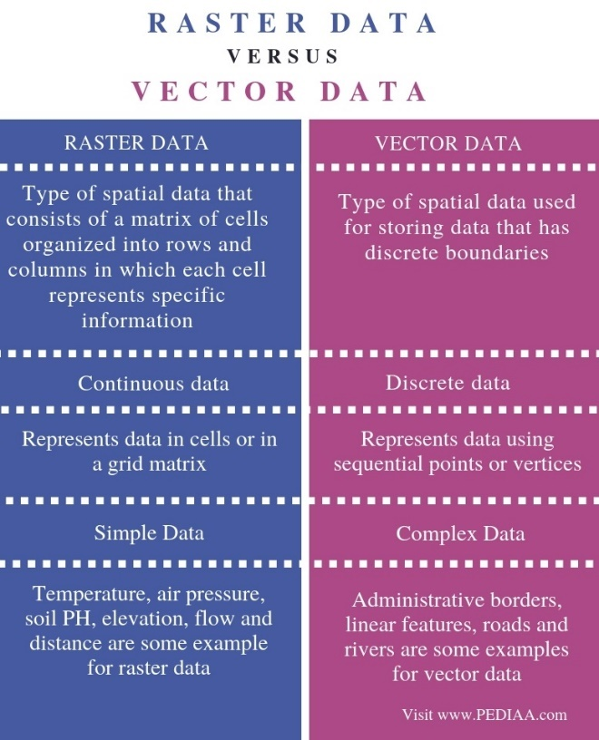

*ModelBuilder*: This drag and drop approach to building workflows in ArcGIS offers visual understandings [1,2]. *ModelBuilder* allows you to create custom tools for multi-step geoprocessing tasks. *ModelBuilder* is a tool for communicating workflows to non-GISers who may not be familiar with GIS jargon. These visualizations are fantastic for communicating project tasks and workflows with upper management.  
*ModelBuilder* isn’t just a pretty picture of your workflow, however. Each shape corresponds to an input, a geoprocessing tool, or an output. The user specifies the parameters before running the model. Where is the data coming from? What parameters (settings) does each step need? Where do you want the outputs to go, and what do you want them to be called?

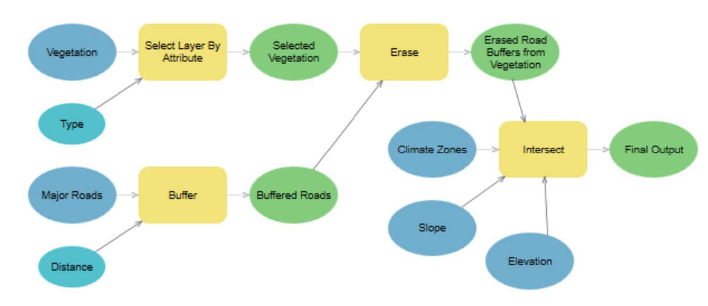

Unfortunately, the bigger the project in *ModelBuilder*, the messier the visuals. *ModelBuilder* has limits, mainly that it is GIS-centric. It won’t (can’t) do much outside of GIS software and datasets. Python can! This well-known programming language has been built into ArcGIS software with its own GIS specific package, ArcPy. This is a Python package of GIS tools and workflows built directly into the software.  
Python allows you to reach beyond the confines of ArcGIS Pro and do external tasks, such as moving files around.  
Watch this short video about Python packages https://www.youtube.com/watch?v=AjYeGIsZpuk  
**A Note on Data Management**  
WARNING: Raster datasets are often large! Depending on how they were encoded, they may compress well. You need to extract all .zip files in order for your files to be read by ArcGIS Pro, Excel or most any other program. Be mindful of your disk space, because some of these rasters expand to hundreds of megabytes when unzipped.  
You will need at least 2GB of free space for this lab.

### Part 2: Raster Data Exploration

Often, you’ll find rasters where each pixel represents a continuous variable, like a height, or color value. Digital Elevation Models (DEMs) are one example of a spatial dataset comprising continuous variables. A DEM is a raster, where each pixel represents a specific elevation (a height above some datum, usually Mean Sea Level [MSL]). Let’s explore a small slice of the GTOPO30 DEM , a 30-arc-second global DEM that was produced by USGS-EROS in 1996 [3,4].

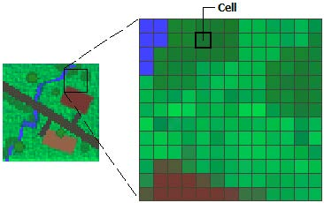

• Download all of the class data to your Classfiles folder for Case Study 2-1 and extract the folder.  
**2.1 Raster data in a spreadsheet** Let’s explore a slice of the GTOPO30 DEM. Let’s first open a plain-text, matrix representation of this data.  
• Open the GTOPO30 folder.  
• Open GTOPO30_ca_clip.csv in Microsoft Excel.  
• Select all cells in the spreadsheet  
o Hint: use Ctrl+A to select all cells  
• Apply a color scale conditional formatting rule so that each cell gets a color according to its value.  
o Hint: Use the conditional formatting tool in the main ribbon (see Fig. 4).  
o Try changing through several different color schemes.

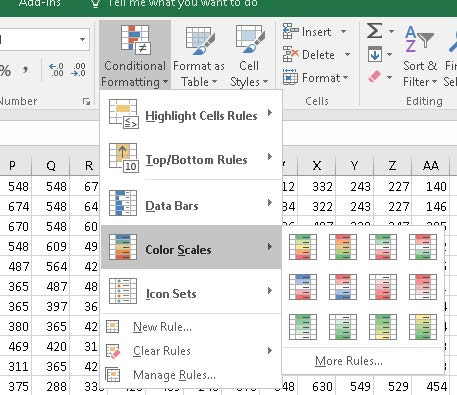

Zoom out and take a screenshot of your window.  
Describe what you see in a few sentences to accompany your screenshot.  
**2.2 Streamlining File Paths**  
When working on remote servers, our folders have weird paths “behind the scenes”…to have a normal/recognizable path and practice good data management, we have to Map a Drive.  
-Right click on the Classfiles folder on your remote server desktop.  
-Select Map a network drive.  
-Select the Z: drive and click finish.  
-That’s it! Now your file path will look nice and streamlined for when we use code later on, and for all labs moving forward.

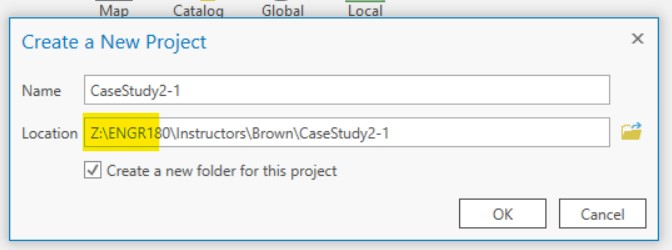

• Add GTOPO30_ca_clip.tif to your workspace. The file is located in the GTOPO30 folder. If the software asks if you’d like to calculate statistics, say yes! It wont take long.  
o Hint: In ArcGIS, there are multiple ways to do the same thing. You can drag and drop some types of files into your map space from Windows Explorer!  
• Add cnty24k09_1_poly.shp to your workspace through Add Data. The file is located in the Shapefiles folder.  
o Wait, why can’t you drag and drop shapefiles? They’re a whole collection of individual files that collectively make up a single shapefile. In Windows Explorer you’ll see lots of “parts” for cnty24k09_1_poly.shp. If you add it in through Add Data in ArcGIS Pro, you only see one because it packages them all together nicely.

[figure not shown]

• Add osm_173351856.shp to your workspace. The file is located in the Shapefiles folder.  
o Which boundary does this shapefile represent? Hint: Check the attribute table by right clicking on the layer to open the table.  
• Turn off your basemap if needed (Did you notice if the Topographic layer shows up by default?)  
• Export a PRODUCTION QUALITY MAP (remember your key map elements from 2c?) showing both shapefiles overlaid over the raster DEM. Use Labels to identify county boundaries.  
o Hint: Change the transparency in your Appearance ribbon for the shapefiles so that all features can be visible on the same map.  
Describe your submission in a few sentences. Be sure to describe the following bullet points for full credit…  
• What is the resolution of the GTOPO30 dataset?(hint: This data originates from USGS)  
• What exactly an arc-second represents (hint: 30 arc seconds = a kilometer). Why are arc seconds a lousy method of measuring distance?  
•If they’re such a lousy method of measuring distance then why are so many rasters defined in angular units (degrees/arc seconds/arc minutes)?  
Be sure to answer all of these questions!

[figure not shown]

### Part 3: Vector to Raster

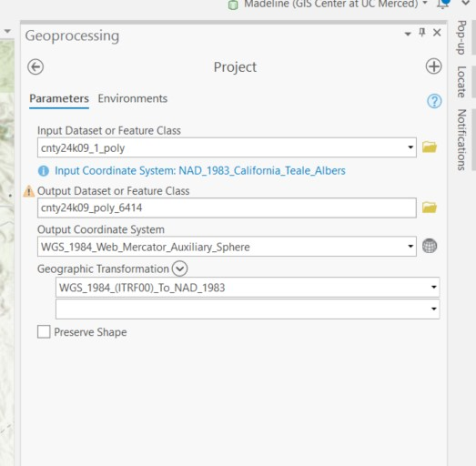

[figure not shown]

See how the new components are gray? That means we need to set our parameters! Plus, we have a tool (P to R) connected to an Output, but no input, right?  
• Double click our *Polygon to Raster* tool to open the empty *Parameters* tab  
• Select the appropriate i15_crop_mcd input. Notice some fields auto populate. That helps save time, but we still need to change some.  
• The “Value field” should correspond to the features in the shapefile that you wish to map onto your pixel values. In this case, we’re going to use the land cover categories present in the “Crop2014” column.  
• Hover your mouse over the *Output Raster Dataset* location. Notice it’s still auto populating to your project folder. We love that! It’s a nice sanity check. Also note the Cellsize in the final row.  
• Change your Output Raster Dataset file name to: mcd_crops_[cellsize] where you’ll replace [cellsize] with the default cell size that the tool recommended in Polygon to Raster.  
 Don’t use the brackets in the file name- just the numbers!  
• For your first run, use the default “Cellsize” and the default “Cell assignment type”  
• Click *Ok.*  
• In the *ModelBuilder* Ribbon, Click *Validate.* This will make sure we’re not missing anything. If you don’t receive any errors, go ahead and click Run! If your new raster doesn’t show up, check your *Table of Contents* to see if it is hiding beneath another layer. Still not showing up? Refresh your *Geodatabase* in your *Catalog* window and it should pop up!  
Export a PRODUCTION QUALITY MAP (all 5 key map elements!) of your crop cover raster and describe your submission in a few sentences. Describe which parameters you used in the polygon-to-raster conversion. Describe how the tool recommends a default cell size. Include a screenshot of your Model.  
*3.2.1 Increasing Complexity in ModelBuilder.*  
Going from vector to raster was pretty quick, but what if you had a manager who wanted to see a workflow of ALL of your steps, in a nice visual package?  
• Return to Section 3.1.  
• Use *ModelBuilder* to repeat from the 4th bullet of step 3.1 through the end of step 3.2 into ONE seamless Model. Hint: Identify which actions/tools you used in 3.1 and 3.2 first. Pull those into the Model window and build out from there. You’ll need to select MERCED County using the Select Layer by Attribute Tool in your Model, after projecting and before clipping.  
Another Hint: If things start looking funky or crowded, use Auto Layout to help you rearrange your Model items.  
• Save all of your outputs with _ModBuild on the ends of the file names.  
• Save this Model to rerun in the future. Note that when you “save as” the file type is tool. Save as *mcd_prj_clip_rasterize*. Go to your Catalog and look in the toolbox in your project folder. There is your new custom tool!!  
Take a screenshot of your ArcGIS Pro window including the Project folder showing all of the _ModBuild outputs in your geodatabase as well as the full model in the main window. Answer the following: What does an oval component mean? What does a rectangular component mean? What is blue/yellow/green symbolic of? What do the arrows mean?

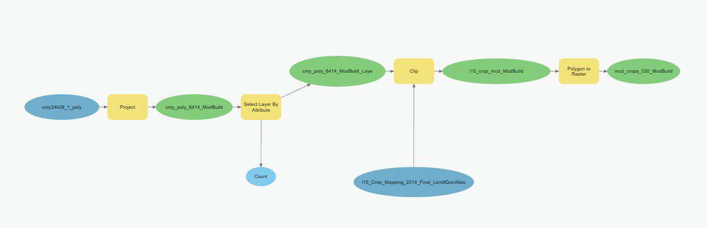

YOU WILL PICK UP WHERE YOU LEAVE OFF FOR THE FOLLOWING LAB. Do NOT delete anything, and make sure you have everything saved before you close out.

## Submission

At the end of this lab, you should have generated the following:  
• 2.1: A screenshot of your GTOPO30 raster, visualized in Excel and short description  
• 2.2: A map of your GTOPO30 raster, imported into ArcGIS Pro, with county and park shapefiles overlaid and short description  
• 3.1: A map of 2014 crop cover, clipped to the boundary of Merced county and short description with metadata info, brief dataset production steps.  
• 3.2: A map of the rasterized dataset of the 2014 Merced crop cover, generated with cell sizes of [default] and accompanying short description.  
• 3.2 Continued: A screenshot of your Model  
• 3.2.1: A screenshot of your Project folder with _ModBuild feature classes showing, along with full view of map window. Short description of model components.

Save all of your spatial products, descriptions of your processing steps, and notes about the results (be sure to answer all the questions) on a flash drive, cloud service or in Classfiles so you dont lose any work. Put the above bulleted submission points into a PDF and upload to CatCourses.

## References

[1] Esri, ArcGIS Pro Documentation. “What is ModelBuilder?” https://pro.arcgis.com/en/pro-app/help/analysis/geoprocessing/modelbuilder/what-is-modelbuilder-.htm  
[2] Esri, ArcGIS Pro Documentation. “ModelBuilder Quick Tour” https://pro.arcgis.com/en/pro-app/help/analysis/geoprocessing/modelbuilder/modelbuilder-quick-tour.htm  
[3] USGS-Long Term Archive. “Global 30 Arc-Second Elevation (GTOPO30)” https://lta.cr.usgs.gov/GTOPO30  
[4] USGS Planetary GIS Web Server. “GTOPO30 Documentation” https://webgis.wr.usgs.gov/globalgis/gtopo30/gtopo30.htm  
[5] Esri, ArcGIS Desktop Documentation. “What is raster data?” http://desktop.arcgis.com/en/arcmap/latest/manage-data/raster-and-images/what-is-raster-data.htm  
[6] Esri, ArcGIS Desktop Documentation. “Raster basics” http://desktop.arcgis.com/en/arcmap/latest/manage-data/geodatabases/raster-basics.htm  
[7] NASA EARTHDATA. “ESD-Approved Standards for use in NASA Earth Science Data Systems – GeoTIFF”. https://earthdata.nasa.gov/user-resources/standards-and-references/geotiff  
[8] US Department of the Interior, US Geological Survey, Multi-Resolution Land Characteristics Consortium. “National Land Cover Database 2011 (NLCD2011)” https://www.mrlc.gov/nlcd11_data.php  
[9] US Department of Agriculture, National Agriculture Statistics Service. “Cropland Data Layer”. https://nassgeodata.gmu.edu/CropScape  
[10] European Commission, Joint Research Centre. “Global Land Cover 2000”. http://forobs.jrc.ec.europa.eu/products/glc2000/glc2000.php  
[11] Land IQ, LLC and California Department of Water Resources. “Statewide Crop Mapping 2014”. https://gis.water.ca.gov/app/cadwrlanduseviewer/  
[12] Esri, ArcGIS Pro Documentation. “An overview of the To Raster toolset” http://pro.arcgis.com/en/pro-app/tool-reference/conversion/an-overview-of-the-to-raster-toolset.htm  
[13] Esri, ArcGIS Pro Documentation. “How Polygon To Raster works” http://pro.arcgis.com/en/pro-app/tool-reference/conversion/how-polygon-to-raster-works.htm 12  
[14] Esri, ArcGIS Pro Documentation. “Polygon to Raster” http://pro.arcgis.com/en/pro-app/tool-reference/conversion/polygon-to-raster.htm  
[15] Esri, ArcGIS Pro Documentation. “Raster to Polygon” https://pro.arcgis.com/en/pro-app/tool-reference/conversion/raster-to-polygon.htm